# 사과의 형이상학

Culture Voyager Vol.01 | 이브 × 뉴턴 × 세잔 × 스피노자

Author

Nakcho Choi

Published

May 2, 2026

## 사과 하나에 문명이 들어 있다

서양 문명사에서 가장 많이 등장하는 과일이 뭔지 생각해본 적 있는가?

포도? 아니다. 올리브? 아니다. **사과**다.

우리에게 사과는 부사, 홍옥, 아오리 — 후르츠(fruit)다. 까서 먹는 거다. 추석에 제사상에 올리는 거다.

하지만 서양 사람들에게 사과는 **진리와 선악 사이에 놓인 메타포**다. 한 입 베어 물면 세상이 바뀐다. 그리고 실제로 네 번 바뀌었다.

## 첫 번째 사과: 이브 — 알겠다는 선택의 대가

창세기의 그 장면. 뱀이 말한다: “이것을 먹으면 선악을 알게 된다.” 이브가 먹는다.

여기서 핵심은 사과가 아니다. 핵심은 **“알겠다”는 행위에 대가가 있다**는 구조다.

- 모르는 상태 = 낙원
- 아는 상태 = 추방

서양 문명의 가장 깊은 곳에 이 공식이 있다: **앎에는 반드시 고통이 따른다.**

그런데 흥미로운 점 — 성경 어디에도 이브가 “먹지 말걸”이라고 후회하는 대목은 없다. 인류 최초의 선택은, 고통을 알면서도 앎을 택한 것이다.

## 두 번째 사과: 뉴턴 — “왜?”라고 묻는 용기

1666년, 울스소프 매너의 정원. 사과가 떨어진다. 뉴턴이 묻는다: “왜 옆으로 안 가고 아래로 떨어지지?”

이게 웃긴 게 — **모든 사람이 봤다.** 사과는 수만 년간 떨어졌다. 수십억 명이 그걸 봤다. 하지만 “왜 아래로?”라고 물은 사람은 없었다.

이브의 사과가 “알겠다”의 대가였다면, 뉴턴의 사과는 **“왜?”라고 묻는 용기**다.

그리고 여기서 결정적 전환이 일어난다: 이브 때는 앎에 **벌**을 줬는데, 뉴턴 때는 앎에 **보상**을 준다. 중력 발견, 천체 운동 설명, 근대 과학 시작.

**앎이 죄에서 미덕으로 바뀌는 전환** — 이것이 과학혁명의 본질이다.

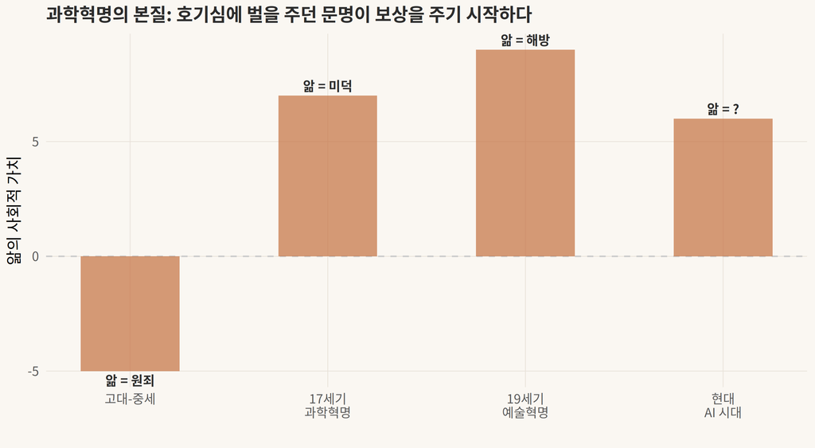

앎의 가치가 뒤집힌 순간

## 세 번째 사과: 세잔 — 존재 전체를 보겠다는 욕망

폴 세잔. 사과를 평생 그린 남자.

“사과 그림이 뭐 대단해?” — 나도 처음엔 그렇게 생각했다. 흐릿하게 사과 그린 거잖아.

하지만 세잔이 한 것을 이해하면 — 졌다.

그 이전의 모든 화가: 사과를 **한 방향에서** 그렸다. 원근법. 소실점. 고정된 관찰자.

세잔: 사과의 **존재 전체**를 그리려 했다. 왼쪽에서 본 것, 오른쪽에서 본 것, 위에서 본 것을 하나의 캔버스에. 2차원으로 3차원 존재를 담으려는 시도.

말도 안 되는 시도다. **그런데 평생 그것만 했다.**

그래서 세잔의 사과를 잘 보면 왼쪽에서 오른쪽으로 돌아가는 느낌이 있다. 흐릿한 게 아니라 — 돌아가는 거다.

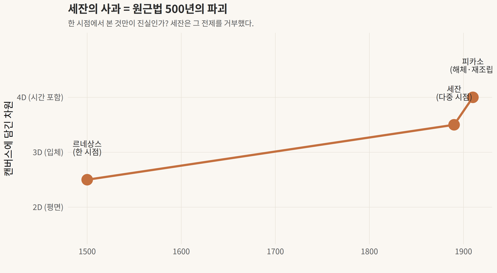

보는 것의 혁명 — 세잔이 없으면 피카소도 없다

이것은 곧 양자역학의 문제이기도 하다. 관찰하면 입자, 관찰하지 않으면 파동. “한 시점에서 본 것”은 존재의 일부일 뿐. 세잔은 물리학보다 30년 먼저 이것을 직감했다.

## 네 번째 사과: 스피노자 — 그래도 심겠다

> “내일 지구의 종말이 오더라도, 나는 오늘 사과나무를 심겠다.”

스피노자. 1656년 유대인 공동체에서 파문. 23세. 렌즈를 깎으며 살고, 《에티카》를 썼다. 살아서 출판 못 했다.

이 남자에게 “사과나무를 심겠다”는 것은 무엇인가?

**결과를 보지 못할 것을 알면서도 시작하는 행위.** 사과나무는 열매까지 5~8년. 내일 종말이면 영원히 열리지 않을 열매. 그런데도 심는다.

왜?

스피노자의 답: **행위의 가치는 결과에 있지 않다.** 나는 사과나무를 심을 수 있는 존재이므로 심는다. 종말이 오든 안 오든, 그것이 나의 본성이다.

## 네 개를 연결하면

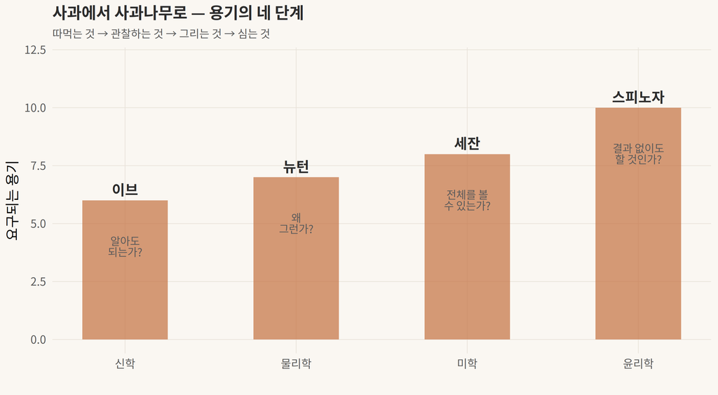

네 개의 사과 — 각 단계가 더 근본적인 용기를 요구한다

**1단계**: 대가를 알면서 아는 용기 (이브) **2단계**: 남들이 묻지 않는 것을 묻는 용기 (뉴턴) **3단계**: 불가능을 알면서 시도하는 용기 (세잔) **4단계**: 결과를 보지 못할 것을 알면서 시작하는 용기 (스피노자)

## 왜 사과”나무”인가

이브는 사과를 **땄다.** 뉴턴은 사과가 **떨어지는** 걸 봤다. 세잔은 사과를 **그렸다.**

스피노자만이 **아직 존재하지 않는 사과**를 말한다. 나무를 심는다. 열매는 8년 뒤.

> **문명이란, 자기가 열매를 보지 못할 나무를 심는 행위의 총합이다.**

세잔이 평생 사과만 그렸듯이. 스피노자가 《에티카》를 출판 못 할 줄 알면서 썼듯이. 우리가 매일 아침 일어나 무언가를 시작하는 것도 — 결과를 확신할 수 없는 행위를 그래도 하는 것이다.

그것이 인간이다.

*Culture Voyager Vol.01 | 2026.05.02*